# A-SA25204160-2025-10-13

SA25204160

2025-10-17

## Question

### 7.3

针对示例 7.9 中的 t 检验，绘制样本量分别为 10、20、30、40 和 50 时的功效曲线，但省略标准误差线。将这些曲线绘制在同一张图上，每条曲线使用不同的颜色或不同的线型，并包含图例。评论功效与样本量之间的关系。

### 7.6

假设使用一个95%对称的t区间来估计均值，但样本数据是非正态的。那么置信区间覆盖均值的概率不一定等于0.95。使用蒙特卡洛实验来估计t区间对于来自χ²(2)分布、样本量n=20的随机样本的覆盖概率。将你的t区间结果与示例7.4中的模拟结果进行比较。（t区间应该比方差区间对于偏离正态性更加稳健。）

### 7.A

使用蒙特卡洛模拟来研究当抽样总体为非正态时，t 检验的经验第一类错误率是否近似等于名义显著性水平 α。t 检验对于轻度偏离正态性是稳健的。讨论抽样总体为 (i) χ²(1)，(ii) Uniform(0,2)，和 (iii) Exponential(rate=1) 情况下的模拟结果。在每种情况下，检验 H₀: μ = μ₀ 对 H₁: μ ≠ μ₀，其中 μ₀ 分别是 χ²(1)、Uniform(0,2) 和 Exponential(1) 的均值。

### 6.15

获取例 6.14 中的分层重要性抽样估计，并将其与例 6.11 的结果进行比较。

## Answer

### 7.3

#### 7.3.1

设置参数：mu0=500, sigma=100, 备选均值序列mu从450到650，间隔10。

#### 7.3.2

定义样本大小向量：sample_sizes <- c(10,20,30,40,50)

#### 7.3.3

对于每个样本大小n，我们进行与示例7.9类似的模拟：

对于每个备选均值mu[i],重复m次实验（例如m=1000）.从均值为mu[i]，标准差为sigma的正态分布中生成n个样本并执行t检验。计算拒绝H0的次数比例（即p值小于0.05）作为功效的估计

#### 7.3.4

将每个样本大小n的功效曲线绘制在同一张图上，使用不同颜色或线型，并添加图例。

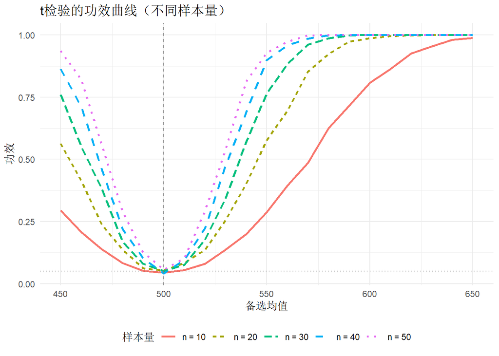

### 7.6

#### 7.6.2

从卡方分布（自由度为2）中生成随机样本。注意，卡方(2)的均值为2，方差为4。

#### 7.6.3

对于每个样本，计算t区间（使用t.test）和方差置信区间（使用卡方分布）。

#### 7.6.4

检查总体均值（2）是否在t区间内，以及总体方差（4）是否在方差置信区间内。

#### 7.6.5

重复m次，计算覆盖概率。

```
## t区间覆盖概率分析 (χ²(2)数据):
```

```
## 样本量 n = 20
```

```
## 蒙特卡洛重复次数 m = 10000
```

```
## 真实均值 μ = 2
```

```
## t区间覆盖概率 = 0.9196
```

```
## 标准误差 = 0.0027
```

```
## 95% 置信区间: [ 0.9143 , 0.9249 ]
```

```
##
## 与名义置信水平 0.95 的比较:
```

```
## 差异 = -0.0304
```

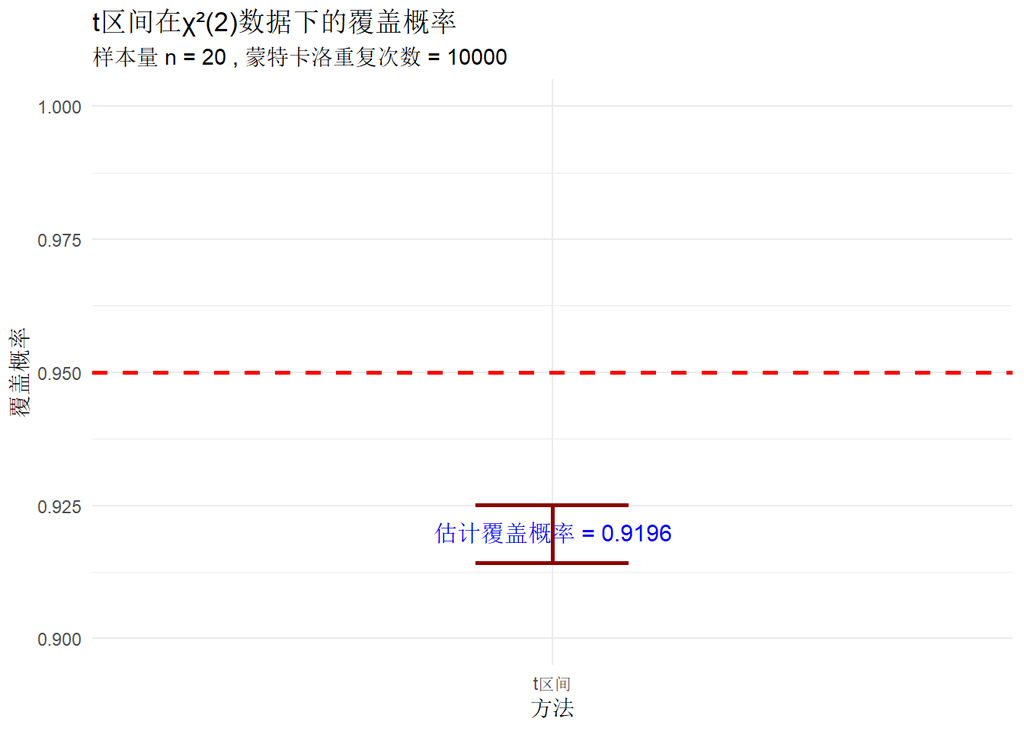

#### 7.6.6

结果与示例7.4中的模拟结果进行比较

```
##
## --- 与方差置信区间的比较 ---
```

```
## 方差区间覆盖概率 = 0.7314
```

```
## 方差区间标准误差 = 0.0044
```

```
##
## --- 稳健性比较 ---
```

```
## t区间覆盖概率与名义水平的差异: 0.0304
```

```
## 方差区间覆盖概率与名义水平的差异: 0.2186
```

```
## 结论: t区间比方差区间更稳健于正态性假设的偏离
```

### 7.A

#### 7.A.1

设置参数

#### 7.A.2

对三种分布分别模拟

#### 7.A.3

计算每种分布的经验第一类错误率

#### 7.A.4

输出结果并讨论

```
## 经验第一类错误率分析 (名义显著性水平 α = 0.05 )
```

```
## 蒙特卡洛重复次数 m = 10000
```

```
##         Chi-squared(1) Uniform(0,2) Exponential(1)
## n = 20          0.1041       0.0520         0.0793
## n = 50          0.0801       0.0473         0.0689
## n = 100         0.0713       0.0495         0.0607
```

```
##
## 标准误差:
```

```
##         Chi-squared(1) Uniform(0,2) Exponential(1)
## n = 20          0.0031       0.0022         0.0027
## n = 50          0.0027       0.0021         0.0025
## n = 100         0.0026       0.0022         0.0024
```

[figure not shown]

```
##
## --- 详细分析 ---
```

```
##
## 样本量 n = 20 :
##    Chi-squared(1) :
##     经验第一类错误率 = 0.1041
##     与名义水平差异 = 0.0541 **
##     稳健性评价: 严重偏离
##    Uniform(0,2) :
##     经验第一类错误率 = 0.052
##     与名义水平差异 = 0.002
##     稳健性评价: 非常稳健
##    Exponential(1) :
##     经验第一类错误率 = 0.0793
##     与名义水平差异 = 0.0293 **
##     稳健性评价: 轻度偏离
##
## 样本量 n = 50 :
##    Chi-squared(1) :
##     经验第一类错误率 = 0.0801
##     与名义水平差异 = 0.0301 **
##     稳健性评价: 严重偏离
##    Uniform(0,2) :
##     经验第一类错误率 = 0.0473
##     与名义水平差异 = -0.0027
##     稳健性评价: 非常稳健
##    Exponential(1) :
##     经验第一类错误率 = 0.0689
##     与名义水平差异 = 0.0189 **
##     稳健性评价: 较为稳健
##
## 样本量 n = 100 :
##    Chi-squared(1) :
##     经验第一类错误率 = 0.0713
##     与名义水平差异 = 0.0213 **
##     稳健性评价: 轻度偏离
##    Uniform(0,2) :
##     经验第一类错误率 = 0.0495
##     与名义水平差异 = -5e-04
##     稳健性评价: 非常稳健
##    Exponential(1) :
##     经验第一类错误率 = 0.0607
##     与名义水平差异 = 0.0107 **
##     稳健性评价: 较为稳健
```

### 6.15

### 6.15.1

初始设置和函数定义

### 6.15.2

标准重要性抽样（例6.11的方法）

### 6.15.3

分层重要性抽样（例6.14的方法）

### 6.15.4

结果显示和比较

```
## === 例6.11结果（标准重要性抽样）===
```

```
## 估计值: 0.5259499
```

```
## 标准误差: 0.0009592083
```

```
## === 例6.14结果（分层重要性抽样）===
```

```
## 估计值: 0.1050058
```

```
## 标准误差: 3.520513e-05
```

```
## === 比较分析 ===
```

```
## 标准误差改进: 96.33 %
```

```
## 理论真值: 0.5247971
```

```
## 标准方法的相对误差: 0.2197 %
```

```
## 分层方法的相对误差: 79.9912 %
```